# UD 2. Modelos avanzados de NLP. Enfoques con Deep Learning

## 2. Modelos de Clasificación (RRNN, GRU y convolucionales 1D)

Índice de contenidos

- 1 - Redes Neuronales Recurrentes
  - 1.1 - LSTM
  - 1.2 - GRU
- 2 - Redes Neuronales Convolucionales
  - 2.1 - Conv 1D
- 3 - RNN con WordEmbeddings
- 4 - Combinando diferentes tipos de redes neuronales
  - 4.1 - Múltiples LSTM
  - 4.2 - Múltiples CNN
  - 4.3 - LSTM + CNN

**IMPORTANTE**: Si no se dispone de GPU, se recomienda ejecutar este notebook desde Google Colab

## 1 - Redes Neuronales Recurrentes

Una de las grandes características de las redes neuronales o, modelos de aprendizaje profundo (Deep Learning) cuando estamos trabajando con texto es el concepto o dimensión de tiempo, es decir, en una oración, el predicado depende del sujeto, como tal, cuando realizamos modelos de forecasting, los sucesos o eventos anteriores tienen incidencia sobre el presente, cuando estamos en NLP sucede lo mismo, la relación de los tokens anteriores tiene incidencia directa, a la hora de clasificar el texto.

Como tal, cuando aparece esta dimensión tiempo surgen las llamadas Redes Neuronales Recurrentes o **RNN** (Recurrent Neural Networks), dentro de esta familia de modelos de Deep Learning aprenderemos los fundamentos de las neuronas recurrentes así como sus conceptos asociados más importantes y, arquitecturas (o topologías) de redes neuronales que cuentan con la dimensión tiempo como son, las **LSTM** o Long Short Term Memory, **Gated Recurrent Units** (GRU)

### 1.1 - LSTM

Las Long Short Term Memory o LSTM, son una variación de las RNN, las cuáles son capaces de recordar dependencias entre términos a lo largo del tiempo, están designadas a recordar grandes periodos de tiempo para resolver el problema de los Vanishing Gradients, esto se consigue ya que una LSTM contiene información en memoria, cada neurona puede leer, escribir y borrar información de su memoria a medida que va avanzando el aprendizaje.

En una neurona de una LSTM se decide, por lo tanto, si añadir u olvidar (borrar) información o actualizarla mediante puertas (gates). Esta asignación de importancia se decide mediante pesos que se van actualizando. En cada neurona LSTM hay tres puertas de información:

- Puerta de entrada (input gate).
- Puerta de olvidar (forget gate).
- Puerta de salida (output gate).

Además, tenemos que añadirle dos componentes más:

- Estado de la celda (cell state), como tal es la propia memoria de la LSTM
- Estado oculto de la celda (Hidden State). Estado oculto externo expuesto otras capas y utilizado para calcular predicciones Sobre el funcionamiento de las puertas, es importante mencionar que su activación está basada en valores entre 0 y 1, generalmente mediante funciones sigmoides donde, 0 significa que no fluye la información a través de la puerta y 1, significa que toda la información fluye a través de la puerta

A continuación, realizaremos la implementación de una LSTM en Python

```python
# Importamos librerías para este ejemplo.
from tensorflow.keras.datasets import imdb
from tensorflow.keras.models import Sequential
from tensorflow.keras.layers import Dense, LSTM, Embedding, Dropout
from tensorflow.keras.preprocessing import sequence

# Si no tienes instalado tensorflow, puedes acceder a la última versión con
# !pip install tensorflow

# NOTA: Si se obtiene algún error entre la conexión de TensorFlow y Keras
#  probar con la versión específica 2.0.2 !pip install tensorflow==2.0.2
```

En primer lugar, vamos a cargar datos sobre los que ya se ha generado un vocabulario, es decir, un objeto llamado **wordindex** en donde cada número representa una palabra. En este caso, se tomará el dataset sobre reviews de películas en **IMBD**, se puede consultar más información sobre los datasets de Keras, en concreto el de imdb desde este enlace.

https://keras.io/api/datasets/imdb/

Si desea accederse a la fuente original de los datos está disponible en: https://ai.stanford.edu/~amaas/data/sentiment/

Como tal, la función `load_data` ya devuelve el conjunto train y test particionado, los datos, están tomados de más de 25.000 películas, realizando un sentiment analysis para cada una de ellas en base a la opinión d elos usuarios, siendo 0 comentario positivo y 1 negativo. Además, para reducir la varianza, vamos a tomar solamente las 5000 palabras más repetidas, es decir, si un hueco de una lista, tiene una palabra que no está en el top 5000 de las más frecuentes se transformará en 0

Cargamos los datos.

```python
(X_train, y_train), (X_test, y_test) = imdb.load_data(num_words=5000)
```

```python
X_train[0:2]
```

```
array([list([1, 14, 22, 16, 43, 530, 973, 1622, 1385, 65, 458, 4468, 66, 3941, 4, 173, 36, 256, 5, 25, 100, 43, 838, 112, 50, 670, 2, 9, 35, 480, 284, 5, 150, 4, 172, 112, 167, 2, 336, 385, 39, 4, 172, 4536, 1111, 17, 546, 38, 13, 447, 4, 192, 50, 16, 6, 147, 2025, 19, 14, 22, 4, 1920, 4613, 469, 4,…
       list([1, 194, 1153, 194, 2, 78, 228, 5, 6, 1463, 4369, 2, 134, 26, 4, 715, 8, 118, 1634, 14, 394, 20, 13, 119, 954, 189, 102, 5, 207, 110, 3103, 21, 14, 69, 188, 8, 30, 23, 7, 4, 249, 126, 93, 4, 114, 9, 2300, 1523, 5, 647, 4, 116, 9, 35, 2, 4, 229, 9, 340, 1322, 4, 118, 9, 4, 130, 4901, 19, …
      dtype=object)
```

```python
y_train[:2]
```

```
array([1, 0], dtype=int64)
```

Keras para procesar la red neuronal, necesitará que todas las frases sean de la misma longitud, por lo tanto, debemos estandarizar todas las frases a la misma longitud, este proceso se conoce como pad sequences, si por ejemplo tomamos como referencia estas dos frases:

- [460, 9634, 341, 2276, 7858]
- [2675, 10079, 8279, 10633, 65, 1278, 8279, 349]

Vemos que la frase 1 tiene 5 tokens y, la frase 2 tiene 8, al realizar **padding**, cuando la frase no llega al máximo de tokens por secuencia simplemente, se agregan ceros al inicio. Por lo tanto, obtendremos:

- [0, 0, 0, 460, 9634, 341, 2276, 7858]
- [2675, 10079, 8279, 10633, 65, 1278, 8279, 349]

Primero, vamos a obtener la frase con más tokens, este valor será nuestra variable **MAX_LEN**

```python
max([len(i) for i in X_train])
```

```
2494
```

En este caso, es un valor muy alto, como tal, deberíamos realizar una limpieza de texto más exahustiva, vamos a truncar este tamaño máximo de palabras a 1000 tokens.

```python
MAX_LEN = 1000
X_train = sequence.pad_sequences(X_train, maxlen = MAX_LEN)
X_test  = sequence.pad_sequences(X_test,  maxlen = MAX_LEN)
```

IMPORTANTE: Si se obtiene un error de este tipo "NotImplementedError: Cannot convert a symbolic Tensor (lstm/strided_slice:0) to a numpy array.", se aconseja bajar Numpy a la versión pip install numpy==1.19.5

```python
# Generamos el modelo
model = Sequential()

# Definimos capa de Embedding
model.add(Embedding(input_dim = 5000, output_dim = 100, input_length=MAX_LEN))

# Definimos la arquitectura de la LSTM
model.add(LSTM(units = 100))

# Apagamos en cada iteracción un 20% de las neuronas para evitar el sobreajuste
model.add(Dropout(0.2))

# Capa de salida
model.add(Dense(units=1, activation="sigmoid")) # La salida es de dimensión 1, 0 o 1

# Definimos función de pérdida y optimizador
model.compile(loss='binary_crossentropy',
              optimizer='adam',
              metrics=['accuracy'])
```

Una vez que ya tenemos nuestro modelo, podemos mostrar el resumen del mismo.

```python
model.summary()
```

```
Model: "sequential"
_________________________________________________________________
Layer (type)                 Output Shape              Param #
=================================================================
embedding (Embedding)        (None, 1000, 100)         500000
_________________________________________________________________
lstm (LSTM)                  (None, 100)               80400
_________________________________________________________________
dropout (Dropout)            (None, 100)               0
_________________________________________________________________
dense (Dense)                (None, 1)                 101
=================================================================
Total params: 580,501
Trainable params: 580,501
Non-trainable params: 0
_________________________________________________________________
```

Finalmente, con la función `fit` podemos entrenar nuestro modelo. En esta parte es importante definir un número de etapas **epochs** de entrenamiento y un tamaño de secuencias en batches o **batch_size**, se aconseja ver este artículo para comprender mejor cómo funciona el tamaño por lotes. https://androidkt.com/ideal-batch-size-for-the-keras-neural-network/

```python
%%time

model_hist = model.fit(X_train, y_train,
                       epochs     = 3,
                       batch_size = 1024)
```

```
Wall time: 31min 39s
```

Tras realizar el entrenamiento completo de la red, que, como vemos puede tardar bastante tiempo, vemos que en cada etapa, se guarda un histórico sobre los valores que hemos pasado al compilador como son la función de pérdida y el accuracy como métrica, algo que suele ser habitual es visualizar estos elementos para ver el rendimiento del modelo, aunque, también es posible acceder a los valores de ambos elementos del compilador, a través del parámetro history

```python
model_hist.history
```

```
{'loss': [0.6440542340278625, 0.4528598487377167, 0.3142048716545105],
 'accuracy': [0.6394000053405762, 0.8093600273132324, 0.8744000196456909]}
```

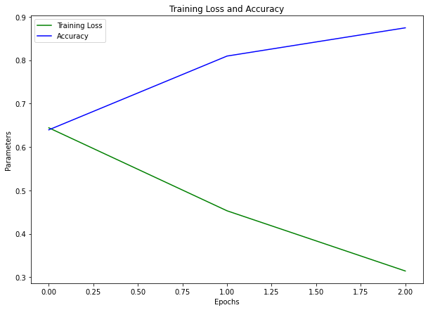

```python
import matplotlib.pyplot as plt

# Observamos el loss del modelo entre el conjunto de entrenamiento y validación
plt.figure(figsize=(10,7))
plt.plot(model_hist.history['loss'], label = 'Training Loss', color = 'green')
plt.plot(model_hist.history['accuracy'], label = 'Accuracy', color = 'blue')
plt.title('Training Loss and Accuracy')
plt.xlabel('Epochs')
plt.ylabel('Parameters')
plt.legend()
plt.show()
```

Finalmente, podemos ver el resultado de predicción con el accuracy score en test, utilizamos la función `evaluate`

```python
%%time

# Mostramos la predicción
scores = model.evaluate(X_test, y_test, verbose=0)
print("Accuracy: %.2f%%" % (scores[1]*100))
```

```
Accuracy: 87.03%
Wall time: 2min 1s
```

```python
# Borramos el modelo para gestionar la memoria ram
del(model_hist, model)
```

Como hemos comprobado anteriormente, la anterior red neuronal, al estar trabajando con una capa de embedding tarda mucho tiempo en entrenarse, vamos a ilistrar de nuevo las LSTM con un modelo más liviano, sin capa de Embedding, la principal diferencia será que la red no tendrá inicialmente pesos en base a palabras vectorizadas y, que tenemos que transformar nuestros arrays a un reshape de Tensor (n,n,n)

```python
# Cargamos datos y, reestructuramos las dimensiones ya que no tenemos capa de Embedding
(X_train, y_train), (X_test, y_test) = imdb.load_data(num_words=5000)

MAX_LEN = 1000
X_train = sequence.pad_sequences(X_train, maxlen = MAX_LEN)
X_test  = sequence.pad_sequences(X_test,  maxlen = MAX_LEN)

# Realizamos el reshape
X_train = X_train.reshape(X_train.shape[0], 1, X_train.shape[1])
X_test  = X_test.reshape(X_test.shape[0], 1, X_test.shape[1])
```

```python
# Generamos el modelo
model = Sequential()

# Definimos capa de Embedding
# model.add(Embedding(input_dim = 5000, output_dim = 100, input_length=MAX_LEN))

# Definimos la arquitectura de la LSTM
model.add(LSTM(units = 100, input_shape = (1, 1000), return_sequences = True))

# Apagamos en cada iteracción un 20% de las neuronas para evitar el sobreajuste
model.add(Dropout(0.2))

# Capa de salida
model.add(Dense(units=1, activation="sigmoid")) # La salida es de dimensión 1, 0 o 1

print(model.summary())

# Definimos función de pérdida y optimizador
model.compile(loss='binary_crossentropy',
              optimizer='adam',
              metrics=['accuracy'])
```

```
Model: "sequential_1"
_________________________________________________________________
Layer (type)                 Output Shape              Param #
=================================================================
lstm_1 (LSTM)                (None, 1, 100)            440400
_________________________________________________________________
dropout_1 (Dropout)          (None, 1, 100)            0
_________________________________________________________________
dense_1 (Dense)              (None, 1, 1)              101
=================================================================
Total params: 440,501
Trainable params: 440,501
Non-trainable params: 0
_________________________________________________________________
None
```

```python
%%time

model_hist_noEmb = model.fit(X_train, y_train,
                       epochs     = 50,
                       batch_size = 1024)
```

```
Wall time: 37.5 s
```

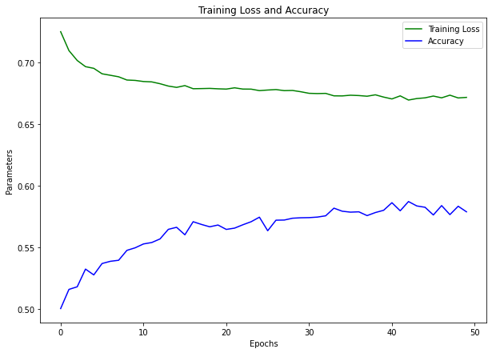

```python
# Observamos el loss del modelo entre el conjunto de entrenamiento y validación
plt.figure(figsize=(10,7))
plt.plot(model_hist_noEmb.history['loss'], label = 'Training Loss', color = 'green')
plt.plot(model_hist_noEmb.history['accuracy'], label = 'Accuracy', color = 'blue')
plt.title('Training Loss and Accuracy')
plt.xlabel('Epochs')
plt.ylabel('Parameters')
plt.legend()
plt.show()
```

```python
%%time

# Mostramos la predicción
scores = model.evaluate(X_test, y_test, verbose=0)
print("Accuracy: %.2f%%" % (scores[1]*100))
```

```
Accuracy: 50.85%
Wall time: 1.5 s
```

Como podemos comprobar, el efecto de las WordEmbeddings es muy alto.

```python
# Borramos el modelo para gestionar la memoria ram
del(model_hist_noEmb, model)
```

### 1.2 - GRU

Las redes Gated Recurrent Unit, GRU pueden verse como una simplificación de la arquitectura LSTM estándar. Como ya hemos visto, un modelo de red de tipo LSTM tiene tres puertas diferentes (input, forget, update) y dos estados diferentes (cell, hidden). Esto solo requiere una gran cantidad de parámetros, tras años de investigación para reducir la complejidad de las LSTM, en 2014 aparecen las primeras publicaciones sobre GRU.

Existen varias diferencias principales entre las GRU y las LSTM: Primero, las GRU combinan dos estados, el estado de celda y el estado oculto final, en un solo estado oculto. Ahora, como efecto secundario de esta simple modificación de no tener dos estados diferentes, se reduce el tiempo considerablemente ya que la puerta de salida estaba decidiendo cuánto del estado de la celda se lee en el estado oculto final. Esta operación reduce considerablemente el número de parámetros en la celda.

A continuación, las GRU introducen una puerta de reinicio que, cuando está cerca de 1, toma la información de estado anterior completa cuando se calcula el estado actual. Además, cuando la puerta de reinicio está cerca de 0, ignora el estado anterior al calcular el estado actual.

Las GRU combinan las puertas de entrada y de olvido en una puerta de actualización. Si la actualización de la puerta es 0, entonces la información de estado completa del estado de celda anterior se inserta en la celda del estado actual, donde nada de la entrada actual se lee en el estado. Si el resultado de la puerta de actualización es 1, todos los inputs actuales son leídos en el estado actual de la celda y ninguno nada de información se propaga desde el estado de la celda anterior

A continuación, realizaremos la implementación de una GRU en Python. Como tal, los datos serán los mismos que en el ejemplo de las únicamente, cambiamos el tipo de capa a GRU https://keras.io/api/layers/recurrent_layers/gru/

```python
import numpy as np
import matplotlib.pyplot as plt

from tensorflow.keras.datasets import imdb
from tensorflow.keras.models import Sequential
from tensorflow.keras.layers import Dense, Embedding, Dropout, GRU
from tensorflow.keras.preprocessing import sequence
```

```python
# Cargamos datos y, reestructuramos las dimensiones ya que no tenemos capa de Embedding
(X_train, y_train), (X_test, y_test) = imdb.load_data(num_words=5000)

MAX_LEN = 1000
X_train = sequence.pad_sequences(X_train, maxlen = MAX_LEN)
X_test  = sequence.pad_sequences(X_test,  maxlen = MAX_LEN)

# Realizamos el reshape
X_train = X_train.reshape(X_train.shape[0], 1, X_train.shape[1])
X_test  = X_test.reshape(X_test.shape[0], 1, X_test.shape[1])
```

```python
# Generamos el modelo
model = Sequential()

# Definimos capa de Embedding
# model.add(Embedding(input_dim = 5000, output_dim = 100, input_length=MAX_LEN))

# Definimos la arquitectura de la LSTM
model.add(GRU(units = 100, input_shape = (1, 1000), return_sequences = True))

# Apagamos en cada iteracción un 20% de las neuronas para evitar el sobreajuste
model.add(Dropout(0.2))

# Capa de salida
model.add(Dense(units=1, activation="sigmoid")) # La salida es de dimensión 1, 0 o 1

# Definimos función de pérdida y optimizador
model.compile(loss='binary_crossentropy',
              optimizer='adam',
              metrics=['accuracy'])
```

```python
print(model.summary())
```

```
Model: "sequential_2"
_________________________________________________________________
Layer (type)                 Output Shape              Param #
=================================================================
gru (GRU)                    (None, 1, 100)            330600
_________________________________________________________________
dropout_2 (Dropout)          (None, 1, 100)            0
_________________________________________________________________
dense_2 (Dense)              (None, 1, 1)              101
=================================================================
Total params: 330,701
Trainable params: 330,701
Non-trainable params: 0
_________________________________________________________________
None
```

```python
%%time

model_gru = model.fit(X_train, y_train,
                       epochs     = 50,
                       batch_size = 1024)
```

```
Wall time: 33.1 s
```

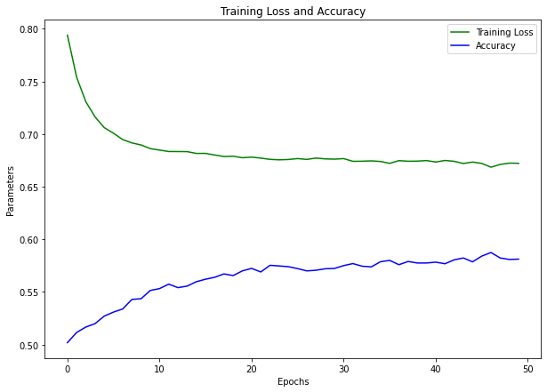

```python
# Observamos el loss del modelo entre el conjunto de entrenamiento y validación
plt.figure(figsize=(10,7))
plt.plot(model_gru.history['loss'], label = 'Training Loss', color = 'green')
plt.plot(model_gru.history['accuracy'], label = 'Accuracy', color = 'blue')
plt.title('Training Loss and Accuracy')
plt.xlabel('Epochs')
plt.ylabel('Parameters')
plt.legend()
plt.show()
```

```python
%%time

# Mostramos la predicción
scores = model.evaluate(X_test, y_test, verbose=0)
print("Accuracy: %.2f%%" % (scores[1]*100))
```

```
Accuracy: 50.39%
Wall time: 1.41 s
```

```python
# Borramos el modelo para gestionar la memoria ram
del(model_gru, model)
```

Como vemos, los resultados son prácticamente iguales, vamos a probar con el modelo completo, con capa de Embedding.

```python
(X_train, y_train), (X_test, y_test) = imdb.load_data(num_words=5000)

MAX_LEN = 1000
X_train = sequence.pad_sequences(X_train, maxlen = MAX_LEN)
X_test  = sequence.pad_sequences(X_test,  maxlen = MAX_LEN)

# Realizamos el reshape
# X_train = X_train.reshape(X_train.shape[0], 1, X_train.shape[1])
# X_test  = X_test.reshape(X_test.shape[0], 1, X_test.shape[1])
```

```python
# Generamos el modelo
model = Sequential()

# Definimos capa de Embedding
model.add(Embedding(input_dim = 5000, output_dim = 100, input_length=MAX_LEN))

# Definimos la arquitectura de la LSTM
model.add(GRU(units = 100))

# Apagamos en cada iteracción un 20% de las neuronas para evitar el sobreajuste
model.add(Dropout(0.2))

# Capa de salida
model.add(Dense(units=1, activation="sigmoid")) # La salida es de dimensión 1, 0 o 1

# Definimos función de pérdida y optimizador
model.compile(loss='binary_crossentropy',
              optimizer='adam',
              metrics=['accuracy'])
```

```python
print(model.summary())
```

```
Model: "sequential_3"
_________________________________________________________________
Layer (type)                 Output Shape              Param #
=================================================================
embedding_1 (Embedding)      (None, 1000, 100)         500000
_________________________________________________________________
gru_1 (GRU)                  (None, 100)               60600
_________________________________________________________________
dropout_3 (Dropout)          (None, 100)               0
_________________________________________________________________
dense_3 (Dense)              (None, 1)                 101
=================================================================
Total params: 560,701
Trainable params: 560,701
Non-trainable params: 0
_________________________________________________________________
None
```

```python
%%time

model_gru_emb = model.fit(X_train, y_train,
                          epochs     = 3,
                          batch_size = 1024)
```

```
Wall time: 53min 6s
```

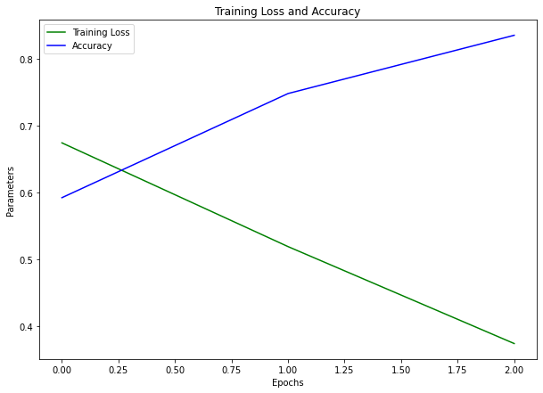

```python
# Observamos el loss del modelo entre el conjunto de entrenamiento y validación
plt.figure(figsize=(10,7))
plt.plot(model_gru_emb.history['loss'], label = 'Training Loss', color = 'green')
plt.plot(model_gru_emb.history['accuracy'], label = 'Accuracy', color = 'blue')
plt.title('Training Loss and Accuracy')
plt.xlabel('Epochs')
plt.ylabel('Parameters')
plt.legend()
plt.show()
```

```python
%%time

# Mostramos la predicción
scores = model.evaluate(X_test, y_test, verbose=0)
print("Accuracy: %.2f%%" % (scores[1]*100))
```

```
Accuracy: 84.83%
Wall time: 1min 57s
```

```python
# Borramos el modelo para gestionar la memoria ram
del(model_gru_emb, model)
```

## 2 - Redes Neuronales Convolucionales

Aunque las Redes Convolucionales, CNN, son más ampliamente utilizadas en problemas de visión computacional, también existen implementaciones para problemas del NLP, las operaciones intrínsecas de las redes convolucionales como la convolución (convolution) y agrupación (pooling) se explicarán en mayor detalle en la unidad de “Introducción a la visión artificial”, ya que, las imágenes deben ser tratadas como matrices y, este tipo de operaciones están especialmente destinadas a trabajar con matrices (Convoluciones 2D). Sin embargo, cuando trabajamos con texto, estamos trabajando con vectores (Convoluciones 1D). No obstante, lo primero que debemos tener en cuenta como siempre en cualquier problema de aprendizaje automático que involucre texto es: Cómo pasar esos textos a números, por otra parte, cómo podemos transformar los textos para trabajarlos como secuencias

Por supuesto, si empleamos Word Embeddings, los valores de la matriz serán completamente diferentes. Una vez que disponemos de nuestros textos como un conjunto de X e Y, se puede comenzar a definir la red neuronal convolucional.

Nuestros datos de entrada serán una matriz de n x k, siendo n la longitud máxima de caracteres (tras aplicar operaciones de padding) y k la dimensión de cada vector. Posteriormente, debemos definir la operación de convolución para secuencias de texto

### 2.1 - Conv 1D

```python
import numpy as np
import matplotlib.pyplot as plt

from tensorflow.keras.datasets import imdb
from tensorflow.keras.models import Sequential
from tensorflow.keras.layers import Conv1D, Dense, Embedding, MaxPooling1D, Dropout
from tensorflow.keras.preprocessing import sequence
```

```python
(X_train, y_train), (X_test, y_test) = imdb.load_data(num_words=5000)

MAX_LEN = 1000
X_train = sequence.pad_sequences(X_train, maxlen = MAX_LEN)
X_test  = sequence.pad_sequences(X_test,  maxlen = MAX_LEN)

# Realizamos el reshape
# X_train = X_train.reshape(X_train.shape[0], 1, X_train.shape[1])
# X_test  = X_test.reshape(X_test.shape[0], 1, X_test.shape[1])
```

En esta ocasión, como estamos trabajando con texto, emplearemos la capa de red Conv1D https://www.tensorflow.org/api_docs/python/tf/keras/layers/Conv1D especialmente tendremos en cuenta dos factores `filter` que se refiere a la dimensionalidad de nuestros datos y, `kernel_size` que es el tamaño del filtro para reducir la dimensionalidad.

```python
# Generamos el modelo
model = Sequential()

# Definimos capa de Embedding
model.add(Embedding(input_dim = 5000, output_dim = 100, input_length=MAX_LEN))

# Definimos la arquitectura de la red Convolucional 1D
model.add(Conv1D(filters=32, kernel_size=3, padding='same', activation='relu'))

# Añadimos una capa de Pooling
model.add(MaxPooling1D(pool_size=2))

# Apagamos en cada iteracción un 20% de las neuronas para evitar el sobreajuste
model.add(Dropout(0.2))

# Capa de salida
model.add(Dense(units=1, activation="sigmoid")) # La salida es de dimensión 1, 0 o 1

# Definimos función de pérdida y optimizador
model.compile(loss='binary_crossentropy',
              optimizer='adam',
              metrics=['accuracy'])
```

```python
print(model.summary())
```

```
Model: "sequential_4"
_________________________________________________________________
Layer (type)                 Output Shape              Param #
=================================================================
embedding_2 (Embedding)      (None, 1000, 100)         500000
_________________________________________________________________
conv1d (Conv1D)              (None, 1000, 32)          9632
_________________________________________________________________
max_pooling1d (MaxPooling1D) (None, 500, 32)           0
_________________________________________________________________
dropout_4 (Dropout)          (None, 500, 32)           0
_________________________________________________________________
dense_4 (Dense)              (None, 500, 1)            33
=================================================================
Total params: 509,665
Trainable params: 509,665
Non-trainable params: 0
_________________________________________________________________
None
```

```python
%%time

model_cnn = model.fit(X_train, y_train,
                      epochs     = 3,
                      batch_size = 1024)
```

```
Wall time: 1min 51s
```

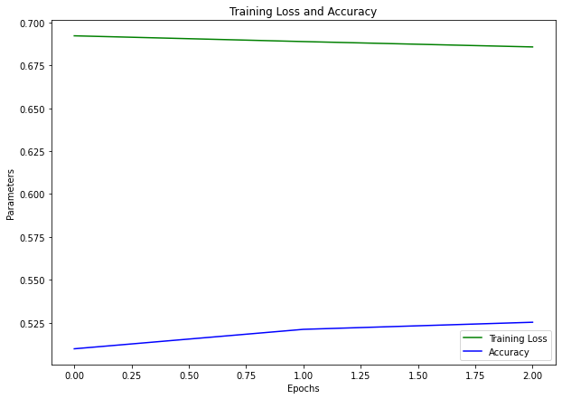

```python
# Observamos el loss del modelo entre el conjunto de entrenamiento y validación
plt.figure(figsize=(10,7))
plt.plot(model_cnn.history['loss'], label = 'Training Loss', color = 'green')
plt.plot(model_cnn.history['accuracy'], label = 'Accuracy', color = 'blue')
plt.title('Training Loss and Accuracy')
plt.xlabel('Epochs')
plt.ylabel('Parameters')
plt.legend()
plt.show()
```

```python
%%time

# Mostramos la predicción
scores = model.evaluate(X_test, y_test, verbose=0)
print("Accuracy: %.2f%%" % (scores[1]*100))
```

```
Accuracy: 52.25%
Wall time: 15.6 s
```

```python
# Borramos el modelo para gestionar la memoria ram
del(model_cnn, model)
```

Como se puede comprobar, en este caso, el reshape es diferente, ya que si tomamos el anterior shape de (25000, 1, 1000), obtendremos este error **Negative dimension size caused by subtracting 2 from 1**.

El error: ValueError: Negative dimension size caused by subtracting 2 from 1 se ve típicamente cuando se trabaja con conv1d en TensorFlow. Este error ocurre cuando las dimensiones de entrada a la función conv1d no son válidas. En particular, se lanza este error cuando el tensor de entrada tiene un tamaño de dimensión de 1 y el tamaño del kernel (que suele especificarse como un parámetro de la función conv1d) se establece en 2 o mayor. En otras palabras, si el kernel size es 3 y nuestro primer elmento de shape es 1, al realizar 1-3, da un resultado negativo, por lo que debemos restructurar el tensor.

Para evitar este error, probamos la solucíón:

- Nos asguramos de que el tensor de entrada a la función conv1d tenga un tamaño de dimensión que sea mayor que el tamaño del kernel. Por ejemplo, si el tamaño de kernel es 2, su tensor de entrada debe tener un tamaño de dimensión de al menos 3.

```python
(X_train, y_train), (X_test, y_test) = imdb.load_data(num_words=5000)

MAX_LEN = 1000
X_train = sequence.pad_sequences(X_train, maxlen = MAX_LEN)
X_test  = sequence.pad_sequences(X_test,  maxlen = MAX_LEN)

# Realizamos el reshape
X_train = X_train.reshape(X_train.shape[0], X_train.shape[1] , 1)
X_test  = X_test.reshape(X_test.shape[0],   X_test.shape[1]  , 1)
```

```python
# Generamos el modelo
model = Sequential()

# Definimos capa de Embedding
# model.add(Embedding(input_dim = 5000, output_dim = 100, input_length=MAX_LEN))

# Definimos la arquitectura de la red Convolucional 1D
model.add(Conv1D(filters=32, kernel_size=3, activation='relu',
                 input_shape = (X_train.shape[1], X_train.shape[2])))

# Añadimos una capa de Pooling
model.add(MaxPooling1D(pool_size=2))

# Apagamos en cada iteracción un 20% de las neuronas para evitar el sobreajuste
model.add(Dropout(0.2))

# Capa de salida
model.add(Dense(units=1, activation="sigmoid")) # La salida es de dimensión 1, 0 o 1

# Definimos función de pérdida y optimizador
model.compile(loss='binary_crossentropy',
              optimizer='adam',
              metrics=['accuracy'])
```

```python
print(model.summary())
```

```
Model: "sequential_5"
_________________________________________________________________
Layer (type)                 Output Shape              Param #
=================================================================
conv1d_1 (Conv1D)            (None, 998, 32)           128
_________________________________________________________________
max_pooling1d_1 (MaxPooling1 (None, 499, 32)           0
_________________________________________________________________
dropout_5 (Dropout)          (None, 499, 32)           0
_________________________________________________________________
dense_5 (Dense)              (None, 499, 1)            33
=================================================================
Total params: 161
Trainable params: 161
Non-trainable params: 0
_________________________________________________________________
None
```

```python
%%time

model_cnn_no_emb = model.fit(X_train, y_train,
                             epochs     = 25,
                             batch_size = 1024)
```

```
Wall time: 5min 41s
```

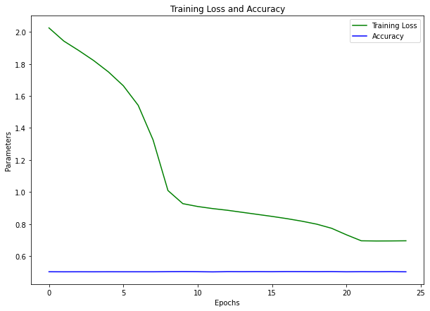

```python
# Observamos el loss del modelo entre el conjunto de entrenamiento y validación
plt.figure(figsize=(10,7))
plt.plot(model_cnn_no_emb.history['loss'], label = 'Training Loss', color = 'green')
plt.plot(model_cnn_no_emb.history['accuracy'], label = 'Accuracy', color = 'blue')
plt.title('Training Loss and Accuracy')
plt.xlabel('Epochs')
plt.ylabel('Parameters')
plt.legend()
plt.show()
```

```python
%%time

# Mostramos la predicción
scores = model.evaluate(X_test, y_test, verbose=0)
print("Accuracy: %.2f%%" % (scores[1]*100))
```

```
Accuracy: 50.21%
Wall time: 4.47 s
```

```python
# Borramos el modelo para gestionar la memoria ram
del(model_cnn_no_emb, model)
```

## 3 - RNN con WordEmbeddings

Para ilustarar este ejemplo, vamos a tomar la función definida para cargar archivos de WordEmbeddings, cargaremos word2vec y, mostraremos cómo preparar la matriz de embedding para entrenar la red neuronal. Lo primero, definimos la carga del modelo de word2vec (si no tienes memoria RAM suficiente, puedes cargar GloVe)

```python
from gensim.models import KeyedVectors

def loadEmbeddingMatrix(typeToLoad, file_dir):
        import gc

        """
        Función desarrollada para obtener una embedding matrix en forma de
         embedding index, en donde cada campo clave sea la palabra del modelo
         pre-entrenado y, cada campo valor el propio vector asociado a cada
         palabra.

         (Requiere cargar gensim.models, por ejemplo: from gensim.models import KeyedVectors)

        input:
        - typeToLoad: string. Nombre del modelo con el que se va a generar la
                      la matriz de embedding, pueden ser:
                      - glove
                      - fasttext
                      - word2vec
        - file_dir: Path con la ruta del archivo a cargar

        output
        - embedding_index (dict)

        """

        # Primero, revisamos el tipo de archivo que vamos a cargar.
        if (typeToLoad == "glove") or (typeToLoad == "fasttext"):
            EMBEDDING_FILE = file_dir

        elif typeToLoad == "word2vec":
            word2vecDict = KeyedVectors.load_word2vec_format(file_dir, binary=True)

        else:
            print("! Has incluido un modelo pre-entrenado de entrada incorrecto !")

        if(typeToLoad=="glove" or typeToLoad=="fasttext" ):
            # Diccionario para ir almacenando las palabras como campo clave:vector
            embeddings_index = dict()

            # Primero, pasamos en un dict como campo clave la palabra y como campo valor cada vector
            f = open(EMBEDDING_FILE, encoding = "utf-8")

            for line in f:
                # Separamos cada array
                values = line.split()

                # Tanto en fasttext como glove, la primera posición del vector
                #  es la palabra
                word = values[0]

                # El resto de posiciones del array son el vector en cuestión
                embeddings_index[word] = np.asarray(values[1:], dtype='float32')

            f.close()
            print('Cargados %s word vectors.' % len(embeddings_index))

        # Word2Vec
        # Glove en versión binaria desde Gensim
        else:
            # Diccionario para ir almacenando las palabras como campo clave:vector
            embeddings_index = dict()
            for word in word2vecDict.vocab:
                embeddings_index[word] = word2vecDict.word_vec(word)
            print('Cargados %s word vectors.' % len(embeddings_index))

        gc.collect()

        return embeddings_index
```

```python
%%time

filename = 'GoogleNews-vectors-negative300.bin.gz'

embedding_index = loadEmbeddingMatrix(typeToLoad     = "word2vec",
                                      file_dir       = filename)
```

```
Cargados 3000000 word vectors.
Wall time: 1min 3s
```

Ahora, necesitamos para cada palabra de nuestro wordIndex (hemos cargado 5000 palabras de IMDB) es inicializar una matriz de tantos 0 como dimensión de las palabras de entrenamiento.

Primero, obtenemos el word index

```python
word_index = imdb.get_word_index()
```

```python
print("Total de palabras únicas en el dataset ", len(word_index))
```

```
Total de palabras únicas en el dataset  88584
```

```python
EMBEDDING_DIM = 300

# Inicializamos la matriz embedding
matriz_embedding = np.zeros((len(word_index)+1, EMBEDDING_DIM)) # X tokens x 300 (longitud de vector en W2vec)
```

Con la matriz de embedding que actualmente está vacía, tenemos que comparar nuestro word to index contra la embedding index, en el caso de que se encuentre una palabra en la embedding index, le asignaremos el vector completo, en caso de que no se encuentre dejaremos un vector de ceros en esa posición.

```python
%%time

# Recorremos cada palabra del word index.
# Si la palabra se encuentra en el embedding index.
# Rellenamos una posición de la matriz de embedding con la representación vectorial
#   de nuestro vocabulario
for word, position in word_index.items():
    try:
        word_vectorized = embedding_index[word]
    except KeyError:
        word_vectorized = None
    if word_vectorized is not None:
        matriz_embedding[position] = word_vectorized
    else:
        pass # Esa posición quedará en [0, 0, 0, 0, ... 0]
```

```
Wall time: 249 ms
```

```python
matriz_embedding[6]
```

```
array([ 0.00704956, -0.07324219,  0.171875  ,  0.02258301, -0.1328125 ,
        0.19824219,  0.11279297, -0.10791016,  0.07177734,  0.02087402,
       -0.12304688, -0.05908203,  0.10107422,  0.01074219,  0.14355469,
        0.25976562, -0.03637695,  0.18554688, -0.07861328, -0.02270508,
       -0.12060547,  0.17773438,  0.04956055,  0.01721191,  0.07958984,
       -0.0456543 , -0.18847656,  0.18945312, -0.02319336,  0.06298828,
        0.09765625, -0.01904297, -0.07910156,  0.15234375,  0.17382812,
        0.1015625 , -0.16308594,  0.11474609,  0.10058594, -0.09277344,
        0.109375  ,  0.05883789, -0.02160645,  0.06347656,  0.04199219,
       -0.0088501 ,  0.03222656,  0.10644531,  0.06445312, -0.11865234,
        0.03051758,  0.06689453,  0.12207031, -0.08300781,  0.171875  ,
        0.07861328,  0.09521484, -0.00778198,  0.02319336,  0.0234375 ,
       -0.0168457 ,  0.15527344, -0.10986328, -0.17675781, -0.11621094,
        0.0234375 , -0.01062012,  0.05273438, -0.13378906,  0.07958984,
        0.07373047,  0.04394531,  0.11523438, -0.02062988,  0.07470703,
       -0.01153564,  0.08056641,  0.04174805,  0.08007812,  0.3515625 ,
        0.09667969, -0.21289062,  0.16503906, -0.078125  ,  0.06982422,
       -0.00139618, -0.09130859,  0.12988281,  0.25195312, -0.01611328,
        0.09326172, -0.14648438, -0.00151062, -0.15136719, -0.02685547,
       -0.15722656,  0.02636719,  0.0859375 ,  0.07177734,  0.07714844,
       -0.0390625 ,  0.05444336, -0.12792969,  0.09130859, -0.18457031,
       -0.03759766, -0.0279541 , -0.08984375, -0.11669922, -0.09863281,
        0.0480957 , -0.16210938, -0.10888672,  0.08496094, -0.0456543 ,
        0.15820312, -0.03808594, -0.08203125,  0.203125  ,  0.08642578,
        0.06933594,  0.03222656, -0.16015625,  0.09472656, -0.0246582 ,
        0.05419922,  0.0279541 ,  0.04492188,  0.16992188,  0.07275391,
       -0.03637695, -0.01025391, -0.01708984, -0.10742188, -0.0007019 ,
       -0.07373047,  0.25390625,  0.05664062,  0.03515625, -0.00860596,
        0.18554688,  0.02148438,  0.26367188, -0.02380371, -0.09912109,
       -0.04125977, -0.06933594, -0.11376953,  0.05004883, -0.05883789,
        0.04614258,  0.08740234,  0.10546875,  0.10644531,  0.0279541 ,
        0.09472656,  0.11621094, -0.17285156, -0.03491211, -0.20800781,
        0.05957031,  0.10400391, -0.00179291,  0.05859375, -0.02978516,
       -0.03759766,  0.04858398, -0.06396484,  0.07958984,  0.06933594,
       -0.10498047, -0.14453125,  0.04345703, -0.06884766, -0.03564453,
       -0.01171875,  0.01367188, -0.06591797,  0.11914062,  0.03125   ,
       -0.04638672, -0.00196838,  0.00735474, -0.05664062,  0.02783203,
        0.08251953, -0.01348877,  0.07177734,  0.14453125,  0.12792969,
        0.04223633,  0.14160156, -0.01806641,  0.02160645, -0.09179688,
        0.13378906, -0.1953125 , -0.05029297, -0.0378418 , -0.09619141,
        0.10302734, -0.10693359, -0.14746094,  0.09960938, -0.23046875,
        0.22753906, -0.07519531,  0.06494141,  0.09179688,  0.046875  ,
        0.06298828,  0.06982422,  0.04614258,  0.09716797, -0.20214844,
        0.19921875,  0.18652344, -0.11962891, -0.14257812,  0.15039062,
       -0.03369141, -0.14550781, -0.00069046, -0.07324219,  0.13378906,
        0.03564453, -0.02294922,  0.02770996, -0.07910156,  0.20703125,
       -0.08349609, -0.04956055,  0.03149414,  0.1484375 ,  0.05566406,
       -0.04492188, -0.07958984,  0.00476074, -0.02075195,  0.06005859,
        0.00476074,  0.01116943,  0.17285156, -0.13476562,  0.03076172,
       -0.07958984,  0.09033203,  0.06103516,  0.07714844, -0.05029297,
       -0.09228516, -0.26757812,  0.10791016,  0.0859375 ,  0.06298828,
        0.10791016, -0.0267334 ,  0.10205078, -0.12060547,  0.05297852,
        0.09472656, -0.16503906,  0.04418945,  0.07226562,  0.04125977,
        0.42578125, -0.10302734, -0.16015625, -0.09033203, -0.06396484,
       -0.0480957 ,  0.14453125,  0.06542969,  0.04931641,  0.05419922,
        0.13574219, -0.01928711, -0.21582031, -0.07421875, -0.14648438,
        0.01147461, -0.16503906, -0.10498047,  0.00320435,  0.13476562,
       -0.00396729, -0.10351562, -0.13964844,  0.10449219, -0.01257324,
       -0.23339844, -0.03637695, -0.09375   ,  0.18261719,  0.02709961,
        0.12792969, -0.02478027,  0.01123047,  0.1640625 ,  0.10693359])
```

Lanzamos el primer ejemplo de rede neuronal, pero ahora, nuestra capa embedding, será la propia matriz que hemos definido.

```python
model = Sequential()
model.add(Embedding(len(word_index)+1, # +1 ya que 0 lo toma de índice, necesitamos una posición más
                    EMBEDDING_DIM,
                    weights = [matriz_embedding],
                    input_length = MAX_LEN,
                    trainable=False) # Que no actualice los pesos iniciales
         )
```

```python
# Definimos la arquitectura de la LSTM
model.add(LSTM(units = 100))

# Apagamos en cada iteracción un 20% de las neuronas para evitar el sobreajuste
model.add(Dropout(0.2))

# Capa de salida
model.add(Dense(units=1, activation="sigmoid")) # La salida es de dimensión 1, 0 o 1

# Definimos función de pérdida y optimizador
model.compile(loss='binary_crossentropy',
              optimizer='adam',
              metrics=['accuracy'])
```

```python
print(model.summary())
```

```
Model: "sequential_6"
_________________________________________________________________
Layer (type)                 Output Shape              Param #
=================================================================
embedding_3 (Embedding)      (None, 1000, 300)         26575500
_________________________________________________________________
lstm_2 (LSTM)                (None, 100)               160400
_________________________________________________________________
dropout_6 (Dropout)          (None, 100)               0
_________________________________________________________________
dense_6 (Dense)              (None, 1)                 101
=================================================================
Total params: 26,736,001
Trainable params: 160,501
Non-trainable params: 26,575,500
_________________________________________________________________
None
```

```python
%%time

model_wordvec = model.fit(X_train, y_train,
                          epochs     = 3,
                          batch_size = 1024)
```

```
Wall time: 1h 13min 20s
```

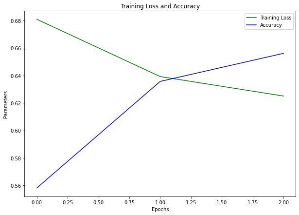

```python
# Observamos el loss del modelo entre el conjunto de entrenamiento y validación
plt.figure(figsize=(10,7))
plt.plot(model_wordvec.history['loss'], label = 'Training Loss', color = 'green')
plt.plot(model_wordvec.history['accuracy'], label = 'Accuracy', color = 'blue')
plt.title('Training Loss and Accuracy')
plt.xlabel('Epochs')
plt.ylabel('Parameters')
plt.legend()
plt.show()
```

```python
%%time

# Mostramos la predicción
scores = model.evaluate(X_test, y_test, verbose=0)
print("Accuracy: %.2f%%" % (scores[1]*100))
```

```
Accuracy: 66.64%
Wall time: 7min 47s
```

```python
# Borramos el modelo para gestionar la memoria ram
del(model_wordvec, model, embedding_index, matriz_embedding)
```

## 4 - Combinando diferentes tipos de redes neuronales

Como tal, las salidas de una red neuronal, pueden ser tomadas en la siguiente capa por una nueva arquitectura de red neuronal, es decir, partir, por ejemplo de una red LSTM y, que la salida de esta red pase a una CNN o viceversa, en este apartado probaremos diferentes combinaciones que combinan varias capas diferentes, conseguir un 1% (o menos) en el proyectos de Aprendizaje Automático puede suponer un gran éxito (menor inversión, mayor tasa de conversión de clientes, etc.), por lo que conseguir la "mejor" configuración de red neuronal, no es una tarea sencilla, a lo largo de esta sección hemos visto principalmente, LSTM, GRU y CNN pero, Keras, provee una gran cantidad de capas y operaciones internas en capas que, utilizadas correctamente según el tipo de dato, harán que nuestras métricas del modelo sean mejores, la documentación oficial de estas capas puede encontrarse en: https://keras.io/api/layers/

NOTA: Estos modelos los probaremos sin capa de Embedding para que tarden menos en ajustar los datos.

Mostraremos una comparativa de resultados.

```python
all_results = {}
```

### 4.1 - Múltiples LSTM

```python
# Cargamos datos y, reestructuramos las dimensiones ya que no tenemos capa de Embedding
(X_train, y_train), (X_test, y_test) = imdb.load_data(num_words=5000)

MAX_LEN = 1000
X_train = sequence.pad_sequences(X_train, maxlen = MAX_LEN)
X_test  = sequence.pad_sequences(X_test,  maxlen = MAX_LEN)

# Realizamos el reshape
X_train = X_train.reshape(X_train.shape[0], 1, X_train.shape[1])
X_test  = X_test.reshape(X_test.shape[0], 1, X_test.shape[1])
```

```python
# Generamos el modelo
model = Sequential()

# Definimos la arquitectura de la LSTM
model.add(LSTM(units = 100, input_shape = (1, 1000), return_sequences = True))

# Apagamos en cada iteracción un 20% de las neuronas para evitar el sobreajuste
model.add(Dropout(0.2))

# Añadimos una segunda capa LSTM, ya no tenemos que definir estructura de entrada
#  viene de la primera LSTM
model.add(LSTM(units = 100, return_sequences = True))

# Otra capa de Dropout, para evitar overfitting.
model.add(Dropout(0.2))

# Capa de salida
model.add(Dense(units=1, activation="sigmoid")) # La salida es de dimensión 1, 0 o 1

print(model.summary())

# Definimos función de pérdida y optimizador
model.compile(loss='binary_crossentropy',
              optimizer='adam',
              metrics=['accuracy'])
```

```
Model: "sequential_8"
_________________________________________________________________
Layer (type)                 Output Shape              Param #
=================================================================
lstm_5 (LSTM)                (None, 1, 100)            440400
_________________________________________________________________
dropout_9 (Dropout)          (None, 1, 100)            0
_________________________________________________________________
lstm_6 (LSTM)                (None, 1, 100)            80400
_________________________________________________________________
dropout_10 (Dropout)         (None, 1, 100)            0
_________________________________________________________________
dense_8 (Dense)              (None, 1, 1)              101
=================================================================
Total params: 520,901
Trainable params: 520,901
Non-trainable params: 0
_________________________________________________________________
None
```

```python
%%time

model_lstm_1 = model.fit(X_train, y_train,
                         epochs     = 50,
                         batch_size = 1024)
```

```
Wall time: 1min 11s
```

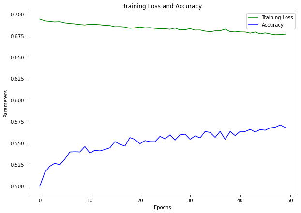

```python
# Observamos el loss del modelo entre el conjunto de entrenamiento y validación
plt.figure(figsize=(10,7))
plt.plot(model_lstm_1.history['loss'], label = 'Training Loss', color = 'green')
plt.plot(model_lstm_1.history['accuracy'], label = 'Accuracy', color = 'blue')
plt.title('Training Loss and Accuracy')
plt.xlabel('Epochs')
plt.ylabel('Parameters')
plt.legend()
plt.show()
```

```python
%%time

# Mostramos la predicción
scores = model.evaluate(X_test, y_test, verbose=0)
print("Accuracy: %.2f%%" % (scores[1]*100))
```

```
Accuracy: 50.89%
Wall time: 2.87 s
```

En este caso, para realizar la comparativa de modelos, no solamente nos vamos a quedar con el resultado de evalaute. Vamos a emplear la función `predict` para obtener los valores 0 y 1

```python
from sklearn.metrics import accuracy_score, confusion_matrix
import seaborn as sns

train_preds = model.predict(X_train)
test_preds = model.predict(X_test)

print("Train Accuracy : {}".format(accuracy_score(y_train, np.argmax(train_preds, axis=1))))
print("Test  Accuracy : {}".format(accuracy_score(y_test,  np.argmax(test_preds,  axis=1))))
```

```
Train Accuracy : 0.5
Test  Accuracy : 0.5
```

Si observamos los valores test_preds, vamos que devuelve probabilidades

```python
test_preds[:5]
```

```
array([[[0.51714027]],

       [[0.4989953 ]],

       [[0.5746667 ]],

       [[0.5219464 ]],

       [[0.5204687 ]]], dtype=float32)
```

Cuando deberían devolver solamente valores 0 y 1 como y_test

```python
y_test[:5]
```

```
array([0, 1, 1, 0, 1], dtype=int64)
```

En este caso, podemos establecer un punto de corte, lo habitual es si <0.5 - 0 si no 1, o, podemos redondear cada número a 0 decimales.

```python
print("Valor original {} valor redondeado {}".format(test_preds[0], np.round(test_preds[0])))
print("Valor original {} valor redondeado {}".format(test_preds[8], np.round(test_preds[8])))
```

```
Valor original [[0.51714027]] valor redondeado [[1.]]
Valor original [[0.44819635]] valor redondeado [[0.]]
```

```python
# Debemos pasar el array a plano, ya que tiene un shape de (25000, 1, 1)
test_preds = np.round(test_preds).ravel().astype(int)
```

```python
test_preds[:5]
```

```
array([1, 0, 1, 1, 1])
```

```python
y_test[:5]
```

```
array([0, 1, 1, 0, 1], dtype=int64)
```

```python
cm = confusion_matrix(y_true=y_test, y_pred = test_preds)
```

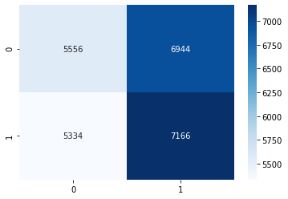

```python
sns.heatmap(cm, annot=True, cmap="Blues", fmt="d")
```

```python
# Guardamos los resultados
all_results["LSTM_1"] = accuracy_score(y_test, np.argmax(train_preds, axis=1))
```

```python
# Borramos el modelo para gestionar la memoria ram
del(model_lstm_1, model)
```

También podemos probar un modelo basado en una red neuronal bidireccional con BILSTM https://keras.io/examples/nlp/bidirectional_lstm_imdb/

```python
from tensorflow.keras.layers import Bidirectional
```

```python
# Generamos el modelo
model = Sequential()

# Generamos una red neuronal Bidireccional
model.add(Bidirectional(LSTM(100, dropout=0.2,
                             recurrent_dropout=0.2, # Recurrent dropout en cada iteracción realiza dropout
                             ), input_shape = (1, 1000)))

# Capa de salida
model.add(Dense(units=1, activation="sigmoid")) # La salida es de dimensión 1, 0 o 1

# Definimos función de pérdida y optimizador
model.compile(loss='binary_crossentropy',
              optimizer='adam',
              metrics=['accuracy'])

print(model.summary())
```

```
Model: "sequential_9"
_________________________________________________________________
Layer (type)                 Output Shape              Param #
=================================================================
bidirectional (Bidirectional (None, 200)               880800
_________________________________________________________________
dense_9 (Dense)              (None, 1)                 201
=================================================================
Total params: 881,001
Trainable params: 881,001
Non-trainable params: 0
_________________________________________________________________
None
```

```python
%%time

model_bidirectional = model.fit(X_train, y_train,
                                epochs     = 50,
                                batch_size = 1024)
```

```
Wall time: 3min 36s
```

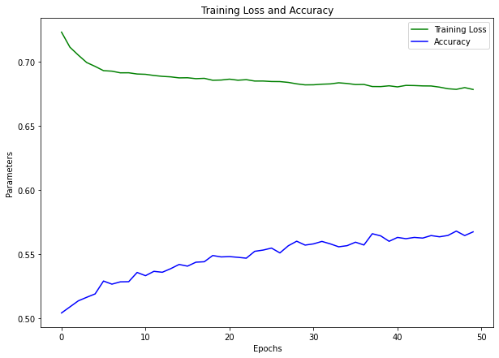

```python
# Observamos el loss del modelo entre el conjunto de entrenamiento y validación
plt.figure(figsize=(10,7))
plt.plot(model_bidirectional.history['loss'], label = 'Training Loss', color = 'green')
plt.plot(model_bidirectional.history['accuracy'], label = 'Accuracy', color = 'blue')
plt.title('Training Loss and Accuracy')
plt.xlabel('Epochs')
plt.ylabel('Parameters')
plt.legend()
plt.show()
```

```python
%%time

# Mostramos la predicción
scores = model.evaluate(X_test, y_test, verbose=0)
print("Accuracy: %.2f%%" % (scores[1]*100))
```

```
Accuracy: 50.72%
Wall time: 4.02 s
```

```python
train_preds = model.predict(X_train)
test_preds = model.predict(X_test)

print("Train Accuracy : {}".format(accuracy_score(y_train, np.argmax(train_preds, axis=1))))
print("Test  Accuracy : {}".format(accuracy_score(y_test,  np.argmax(test_preds,  axis=1))))
```

```
Train Accuracy : 0.5
Test  Accuracy : 0.5
```

```python
# Debemos pasar el array a plano, ya que tiene un shape de (25000, 1, 1)
test_preds = np.round(test_preds).ravel().astype(int)
```

```python
cm = confusion_matrix(y_true=y_test, y_pred = test_preds)
```

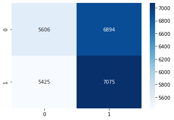

```python
sns.heatmap(cm, annot=True, cmap="Blues", fmt="d")
```

```python
# Guardamos los resultados
all_results["BI_LSTM"] = accuracy_score(y_test, np.argmax(train_preds, axis=1))
```

```python
# Borramos el modelo para gestionar la memoria ram
del(model_bidirectional, model)
```

### 4.2 - Múltiples CNN

Es importante volver a redimensionar los datos de forma acorde a la CNN

```python
(X_train, y_train), (X_test, y_test) = imdb.load_data(num_words=5000)

MAX_LEN = 1000
X_train = sequence.pad_sequences(X_train, maxlen = MAX_LEN)
X_test  = sequence.pad_sequences(X_test,  maxlen = MAX_LEN)

# Realizamos el reshape
X_train = X_train.reshape(X_train.shape[0], X_train.shape[1] , 1)
X_test  = X_test.reshape(X_test.shape[0],   X_test.shape[1]  , 1)
```

```python
# Generamos el modelo
model = Sequential()

# Definimos capa de Embedding
# model.add(Embedding(input_dim = 5000, output_dim = 100, input_length=MAX_LEN))

# Definimos la arquitectura de la red Convolucional 1D
model.add(Conv1D(filters=32, kernel_size=3, activation='relu',
                 input_shape = (X_train.shape[1], X_train.shape[2])))
# Nueva red CNN
model.add(Conv1D(filters=32, kernel_size=3, activation='relu'))

# Añadimos una capa de Pooling
model.add(MaxPooling1D(pool_size=2))

# Capa Dropout
model.add(Dropout(0.2))

# Añadimos otra capa CNN
model.add(Conv1D(filters=64, kernel_size=3, activation='relu'))
model.add(Conv1D(filters=64, kernel_size=3, activation='relu'))

# Nueva capa Pooling
model.add(MaxPooling1D(pool_size=2))

# Apagamos en cada iteracción un 20% de las neuronas para evitar el sobreajuste
model.add(Dropout(0.2))

# Capa de salida
model.add(Dense(units=1, activation="sigmoid")) # La salida es de dimensión 1, 0 o 1

# Definimos función de pérdida y optimizador
model.compile(loss='binary_crossentropy',
              optimizer='adam',
              metrics=['accuracy'])
```

```python
print(model.summary())
```

```
Model: "sequential_10"
_________________________________________________________________
Layer (type)                 Output Shape              Param #
=================================================================
conv1d_2 (Conv1D)            (None, 998, 32)           128
_________________________________________________________________
conv1d_3 (Conv1D)            (None, 996, 32)           3104
_________________________________________________________________
max_pooling1d_2 (MaxPooling1 (None, 498, 32)           0
_________________________________________________________________
dropout_11 (Dropout)         (None, 498, 32)           0
_________________________________________________________________
conv1d_4 (Conv1D)            (None, 496, 64)           6208
_________________________________________________________________
conv1d_5 (Conv1D)            (None, 494, 64)           12352
_________________________________________________________________
max_pooling1d_3 (MaxPooling1 (None, 247, 64)           0
_________________________________________________________________
dropout_12 (Dropout)         (None, 247, 64)           0
_________________________________________________________________
dense_10 (Dense)             (None, 247, 1)            65
=================================================================
Total params: 21,857
Trainable params: 21,857
Non-trainable params: 0
_________________________________________________________________
None
```

```python
%%time

model_cnn_2 = model.fit(X_train, y_train,
                        epochs     = 15,
                        batch_size = 1024)
```

```
Wall time: 17min 49s
```

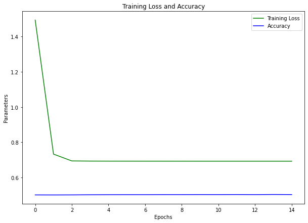

```python
# Observamos el loss del modelo entre el conjunto de entrenamiento y validación
plt.figure(figsize=(10,7))
plt.plot(model_cnn_2.history['loss'], label = 'Training Loss', color = 'green')
plt.plot(model_cnn_2.history['accuracy'], label = 'Accuracy', color = 'blue')
plt.title('Training Loss and Accuracy')
plt.xlabel('Epochs')
plt.ylabel('Parameters')
plt.legend()
plt.show()
```

```python
%%time

# Mostramos la predicción
scores = model.evaluate(X_test, y_test, verbose=0)
print("Accuracy: %.2f%%" % (scores[1]*100))
```

```
Accuracy: 50.07%
Wall time: 13.9 s
```

```python
train_preds = model.predict(X_train)
test_preds = model.predict(X_test)

print("Train Accuracy : {}".format(accuracy_score(y_train, np.argmax(train_preds, axis=1))))
print("Test  Accuracy : {}".format(accuracy_score(y_test,  np.argmax(test_preds,  axis=1))))
```

```
Train Accuracy : 4e-05
Test  Accuracy : 4e-05
```

```python
test_preds = np.array([array_[0][0] for array_ in test_preds]).astype(int)
```

```python
cm = confusion_matrix(y_true=y_test, y_pred = test_preds)
```

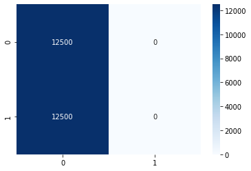

```python
sns.heatmap(cm, annot=True, cmap="Blues", fmt="d")
```

```python
# Guardamos los resultados
all_results["CNN_2"] = accuracy_score(y_test, np.argmax(train_preds, axis=1))
```

```python
# Borramos el modelo para gestionar la memoria ram
del(model_cnn_2, model)
```

### 4.3 - LSTM + CNN

Generamos un último modelo que tome como entrada una red convolucional y, pase la salida a una LSTM

```python
# Generamos el modelo
model = Sequential()

# Definimos la arquitectura de la red Convolucional 1D
model.add(Conv1D(filters=32, kernel_size=3, activation='relu',
                 input_shape = (X_train.shape[1], X_train.shape[2])))
# Nueva red CNN
model.add(Conv1D(filters=32, kernel_size=3, activation='relu'))

# Añadimos una capa de Pooling
model.add(MaxPooling1D(pool_size=2))

# Capa Dropout
model.add(Dropout(0.2))

# Añadimos una capa LSTM
model.add(LSTM(100))

# Apagamos en cada iteracción un 20% de las neuronas para evitar el sobreajuste
model.add(Dropout(0.2))

# Capa de salida
model.add(Dense(units=1, activation="sigmoid")) # La salida es de dimensión 1, 0 o 1

# Definimos función de pérdida y optimizador
model.compile(loss='binary_crossentropy',
              optimizer='adam',
              metrics=['accuracy'])

print(model.summary())
```

```
Model: "sequential_11"
_________________________________________________________________
Layer (type)                 Output Shape              Param #
=================================================================
conv1d_6 (Conv1D)            (None, 998, 32)           128
_________________________________________________________________
conv1d_7 (Conv1D)            (None, 996, 32)           3104
_________________________________________________________________
max_pooling1d_4 (MaxPooling1 (None, 498, 32)           0
_________________________________________________________________
dropout_13 (Dropout)         (None, 498, 32)           0
_________________________________________________________________
lstm_8 (LSTM)                (None, 100)               53200
_________________________________________________________________
dropout_14 (Dropout)         (None, 100)               0
_________________________________________________________________
dense_11 (Dense)             (None, 1)                 101
=================================================================
Total params: 56,533
Trainable params: 56,533
Non-trainable params: 0
_________________________________________________________________
None
```

```python
%%time

model_cnn_lstm = model.fit(X_train, y_train,
                        epochs     = 15,
                        batch_size = 1024)
```

```
Wall time: 2h 5min 7s
```

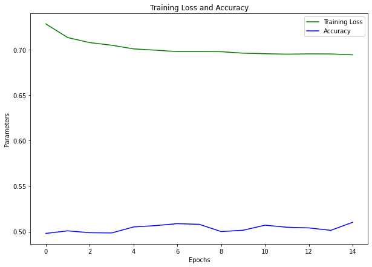

```python
# Observamos el loss del modelo entre el conjunto de entrenamiento y validación
plt.figure(figsize=(10,7))
plt.plot(model_cnn_lstm.history['loss'], label = 'Training Loss', color = 'green')
plt.plot(model_cnn_lstm.history['accuracy'], label = 'Accuracy', color = 'blue')
plt.title('Training Loss and Accuracy')
plt.xlabel('Epochs')
plt.ylabel('Parameters')
plt.legend()
plt.show()
```

```python
%%time

# Mostramos la predicción
scores = model.evaluate(X_test, y_test, verbose=0)
print("Accuracy: %.2f%%" % (scores[1]*100))
```

```
Accuracy: 50.30%
Wall time: 1min 55s
```

```python
train_preds = model.predict(X_train)
test_preds = model.predict(X_test)

print("Train Accuracy : {}".format(accuracy_score(y_train, np.argmax(train_preds, axis=1))))
print("Test  Accuracy : {}".format(accuracy_score(y_test,  np.argmax(test_preds,  axis=1))))
```

```
Train Accuracy : 0.5
Test  Accuracy : 0.5
```

```python
# Debemos pasar el array a plano, ya que tiene un shape de (25000, 1, 1)
test_preds = np.round(test_preds).ravel().astype(int)
```

```python
cm = confusion_matrix(y_true=y_test, y_pred = test_preds)
```

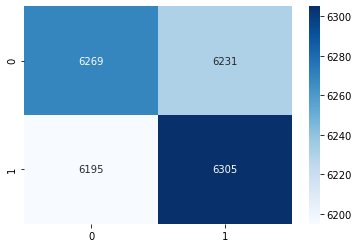

```python
sns.heatmap(cm, annot=True, cmap="Blues", fmt="d")
```

```python
# Guardamos los resultados
all_results["LSTM_CNN"] = accuracy_score(y_test, np.argmax(train_preds, axis=1))
```

```python
# Borramos el modelo para gestionar la memoria ram
del(model_cnn_lstm, model)
```

Finalmente, mostrarmos resultados

```python
import pandas as pd

all_results_df = pd.DataFrame.from_dict(all_results, orient='index', columns = ["Accuracy"])

all_results_df.style.background_gradient(cmap="Blues")
```

|  | Accuracy |
| --- | --- |
| LSTM_1 | 0.500000 |
| BI_LSTM | 0.500000 |
| CNN_2 | 0.000040 |
| LSTM_CNN | 0.500000 |

Vemos que, en líneas generales, los resultados salvo, en la segunda CNN son todos iguales, por lo tanto, donde se obtienen grandes diferencias, es implementando dichos modelos con matrices de Embedding.